# CategoricalQuantGen: a compositional quantitative-genetics model in Julia

Illustrating the AlgebraicJulia layer and parity with the reference C simulation

## What this package is

`CategoricalQuantGen` re-expresses the quantitative-genetics model of Pagel et al. (*Scientific Reports*, 2025) — shipped as the monolithic C simulation **QTSim** in `Repository/` — as a *composition* of independent evolutionary operators. It is organised in two levels:

- an **abstract** layer, using **Catlab.jl / ACSets.jl**: the population is an attributed C-set (ACSet), and each biological process is a first-class `Operator` that we compose with the unicode operators `⋅` (diagrammatic composition) and `⊗` (stratification);
- a **lowered** layer: a fast array kernel whose numerics replicate QTSim, so the model’s output is *statistically consistent* with the C reference.

The mathematical facts the decomposition relies on are separately proved in Lean 4 (`lean/`). This vignette walks through the model and closes by demonstrating parity with the original C code.

```julia
using CategoricalQuantGen
using Random, Statistics, Printf
using CairoMakie
using HypothesisTests
# CairoMakie/Makie also export `lift` (Observables) and `⋅`/`⊗` (LinearAlgebra);
# bind these names to the CategoricalQuantGen (Catlab) versions explicitly.
import CategoricalQuantGen: lift, ⋅, ⊗
CairoMakie.activate!(type = "png")
```

## Parameters and derived quantities

A run is configured by a `Params`. The field names and defaults mirror QTSim’s options; the derived quantities mirror `CaclOptParm` / `GetAnalyticalFitSD` and have Lean counterparts in `Heritability.lean`.

```julia
p = Params(
    PopSize = 1000, Ploidy = 2, NoQTL = 1, NoGenerations = 6500,
    PhenotypeVar = 0.02, Heritability = 0.5, MutationScalar = 0.001,
    ChangeFitnessGen = 5000, ChangeFitnessSD = 0.30,
    MoveFitnessSDGen = 5000, MoveFitnessSD = 1.0, MoveType = :phenotype,
)

@printf("V_G  (= h²·V_P)          = %.4g\n", geneticVar(p))
@printf("V_E  (= (1−h²)·V_P)      = %.4g\n", envVar(p))
@printf("V_P  = V_G + V_E         = %.4g\n", geneticVar(p) + envVar(p))
@printf("analytical width ω       = %.4g\n", analyticalFitSD(p))
@printf("mutational input m·V_E   = %.3e\n", muteVar(p))
```

```
V_G  (= h²·V_P)          = 0.01
V_E  (= (1−h²)·V_P)      = 0.01
V_P  = V_G + V_E         = 0.02
analytical width ω       = 3.162
mutational input m·V_E   = 1.000e-05
```

The additive decomposition `V_P = V_G + V_E` (the `Cov(G,E)=0` assumption) and the width formula `ω = V_G / √(m·V_E)` are exactly the statements proved in `lean/CategoricalQuantGen/Heritability.lean`.

## Running a simulation

`simulate` runs the model and returns per-generation statistics. Here the population equilibrates under weak stabilizing selection, then at generation 5000 the fitness optimum starts moving (directional selection) and the width narrows.

```julia
out = simulate(p; seed = 20240724)
(; extinct = out.extinct, generations = length(out.gen))
```

```
(extinct = false, generations = 6500)
```

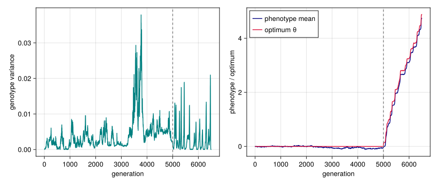

Figure 1: Genotype variance and the phenotype tracking the moving optimum. The dashed line marks the onset of directional selection (generation 5000).

```julia
fig = Figure(size = (900, 380))

ax1 = Axis(fig[1, 1], xlabel = "generation", ylabel = "genotype variance")
lines!(ax1, out.gen, out.geno_var, color = :teal)
vlines!(ax1, [p.MoveFitnessSDGen], color = :gray, linestyle = :dash)

ax2 = Axis(fig[1, 2], xlabel = "generation", ylabel = "phenotype / optimum")
lines!(ax2, out.gen, out.pheno_mean, label = "phenotype mean", color = :navy)
lines!(ax2, out.gen, out.theta, label = "optimum θ", color = :crimson)
vlines!(ax2, [p.MoveFitnessSDGen], color = :gray, linestyle = :dash)
axislegend(ax2, position = :lt)

fig
```

## The population as an ACSet (abstract layer)

The abstract layer represents a population as a Catlab/ACSets attributed C-set following the schema `SchPopulation`: alleles point to individuals via a morphism `owner : Allele → Individual`, allele effects and per-individual environment/genotype/phenotype/fitness are attributes. `lift` materialises the array state as an ACSet; `genotypes` then computes each individual’s genotype *at the categorical level* by summing allele effects grouped via `incident(pop, i, :owner)`.

```julia
w = World(p)
rng = MersenneTwister(1)
for k in eachindex(w.genome); w.genome[k] = 0.1 * randn(rng); end
for i in 1:p.PopSize; w.env[i] = sqrt(envVar(p)) * randn(rng); end
CategoricalQuantGen.develop!(w)

pop = lift(w)                       # World  →  ACSet
@printf("ACSet individuals: %d,  alleles: %d\n",
        length(genotypes(pop)), p.PopSize * p.NoQTL * p.Ploidy)

# genotype computed on the ACSet matches the kernel; and lift/lower round-trips
@printf("genotypes(pop) ≈ kernel genotype:  %s\n", genotypes(pop) ≈ w.genotype)
@printf("lift∘lower recovers genome exactly: %s\n",
        genome_from_acset(pop, p.NoQTL, p.Ploidy) == w.genome)
```

```
ACSet individuals: 1000,  alleles: 2000
genotypes(pop) ≈ kernel genotype:  true
lift∘lower recovers genome exactly: true
```

## Composing a generation with `⋅`

Each biological process is an `Operator`. One generation is their diagrammatic composite

$$\text{generation} \;=\; \texttt{develop} \cdot \texttt{select} \cdot
\texttt{reproduce} \cdot \texttt{mutate} \cdot \texttt{swap},$$

read left-to-right (Catlab’s `⋅`). This is the executable image of the Lean theorem `generation = mutate ∘ reproduce ∘ select` (`Composition.lean`, where `∘` is right-to-left). Driving a run with the composed operator is *bit-identical* to the hand-written kernel loop under the same seed:

```julia
a = run!(World(p), MersenneTwister(7))
b = run_composed(World(p), MersenneTwister(7))
@printf("generation is an Operator:              %s\n", generation isa Operator)
@printf("run_composed == run!  (genotype var):   %s\n", a.geno_var == b.geno_var)
@printf("run_composed == run!  (phenotype mean): %s\n", a.pheno_mean == b.pheno_mean)
```

```
generation is an Operator:              true
run_composed == run!  (genotype var):   true
run_composed == run!  (phenotype mean): true
```

## Stratifying with `⊗`

`⊗` stratifies the model into a discrete metapopulation of demes. Operators lift to act per stratum, and `migrate!` moves individuals between demes while conserving the total population.

```julia
s = p ⊗ Demes(4)
rng = MersenneTwister(3)
for w in s.demes, i in 1:w.p.PopSize
    w.env[i] = sqrt(envVar(p)) * randn(rng)
end

@printf("demes: %d,  total population: %d\n", ndemes(s), totalpop(s))
generation(s, rng)                      # one operator, applied to every deme
before = totalpop(s)
m = migrate!(s, rng; rate = 0.1)        # exchange ~10% between demes
@printf("after one generation, all demes advanced: %s\n", all(w -> w.gen == 1, s.demes))
@printf("migrated %d individuals; total conserved: %s\n", m.count, totalpop(s) == before)
```

```
demes: 4,  total population: 4000
after one generation, all demes advanced: true
migrated 390 individuals; total conserved: true
```

## Parity with the original C simulation

To show that the compositional Julia model is a faithful re-expression of the reference C code — not merely close on average — we compare the *full distributions* of several summary statistics. For each of two scenarios we run both implementations `R` times and overlay the **empirical CDFs** of each metric, testing equality of distribution with a two-sample **Kolmogorov–Smirnov** test. The two use different RNGs (Julia’s MersenneTwister vs GSL’s mt19937), so individual runs differ; the claim is that they draw from the *same distribution* (large KS `p`, small KS `D`).

**Note**

We compare **phenotypic advance** (how far the mean phenotype moves during directional selection) rather than the *adaptation lag* θ − mean(z). In this model the optimum is set each generation to mean(z) + √(V_P)·MoveFitnessSD, so the lag is a **deterministic constant** (≈ 0.1414 here), not a random variable: both implementations reproduce it to ~1e-9, but its “distribution” is a point mass, so an empirical-CDF / KS comparison of it measures only floating-point print precision (QTSim emits 6 decimals), not model behaviour.

```julia
const QTSIM = normpath(joinpath(@__DIR__, "..", "..",
                                "Repository", "Code", "QTSim", "src", "QTSim"))
isfile(QTSIM) || error("QTSim binary not found at $QTSIM — build it (see README.md).")

function write_opts(path, q::Params, seed::Int)
    open(path, "w") do io
        println(io, "Sample $(q.Sample)");  println(io, "PopSize $(q.PopSize)")
        println(io, "NoQTL $(q.NoQTL)");     println(io, "Generations $(q.NoGenerations)")
        println(io, "Ploidy $(q.Ploidy)")
        q.MoveFitnessSDGen != -1 && println(io, "MoveFitnessSD $(q.MoveFitnessSDGen) $(q.MoveFitnessSD)")
        q.ChangeFitnessGen  != -1 && println(io, "ChangeFitnessSD $(q.ChangeFitnessGen) $(q.ChangeFitnessSD)")
        println(io, "OptimumMoveType $(q.MoveType)")
        println(io, "PhenotypeVar $(q.PhenotypeVar)")
        println(io, "MutationScalar $(q.MutationScalar)")
        println(io, "Heritability $(q.Heritability)")
        println(io, "MutationRatePerGamete $(q.MutationRatePerGamete)")
        q.InitFitnessSD >= 0 && println(io, "InitFitnessSD $(q.InitFitnessSD)")
        println(io, "Seed $seed")
    end
end

# Run QTSim and parse its stdout into the same shape as `simulate`'s output.
function run_qtsim(q::Params, seed::Int)
    opts = tempname() * ".txt"; write_opts(opts, q, seed)
    o = try; read(`$QTSIM $opts`, String); finally; rm(opts; force = true); end
    gen = Int[]; pmean = Float64[]; gvar = Float64[]; nsurv = Int[]; θ = Float64[]
    inbody = false
    for line in split(o, '\n')
        startswith(line, "Pop all died") &&
            return (gen=gen, pheno_mean=pmean, geno_var=gvar, nsurv=nsurv, theta=θ, extinct=true)
        startswith(line, "Generation") && (inbody = true; continue)
        (inbody && !isempty(strip(line))) || continue
        f = split(line, '\t'); length(f) < 6 && continue
        push!(gen, parse(Int, f[1]));  push!(pmean, parse(Float64, f[2]))
        push!(gvar, parse(Float64, f[4])); push!(nsurv, parse(Int, f[5]))
        push!(θ, parse(Float64, f[6]))
    end
    (gen=gen, pheno_mean=pmean, geno_var=gvar, nsurv=nsurv, theta=θ, extinct=false)
end

# Metric extractors, defined once and applied to Julia and C output alike.
win(r, lo, hi) = findall(g -> lo <= g <= hi, r.gen)
eq_VG(r, lo, hi)  = mean(@view r.geno_var[win(r, lo, hi)])
end_VG(r, q)      = mean(@view r.geno_var[win(r, q.NoGenerations - 100, q.NoGenerations)])
survfrac(r, q)    = mean(@view r.nsurv[win(r, q.MoveFitnessSDGen, q.NoGenerations)]) / q.PopSize
tavg_VG(r, q)     = mean(@view r.geno_var[win(r, 1000, q.MoveFitnessSDGen - 1)])  # pre-move, noise-averaged
function pheno_advance(r, q)   # stochastic: distance the mean advances under selection
    onset = win(r, q.MoveFitnessSDGen, q.MoveFitnessSDGen + 10)
    fin   = win(r, q.NoGenerations - 100, q.NoGenerations)
    mean(r.pheno_mean[fin]) - mean(r.pheno_mean[onset])
end

# KS statistic D (max eCDF gap) for display; p-value from HypothesisTests.
function ks_D(a, b)
    xs = sort(vcat(a, b))
    maximum(abs(count(<=(x), a) / length(a) - count(<=(x), b) / length(b)) for x in xs)
end
ks_p(a, b) = pvalue(ApproximateTwoSampleKSTest(Float64.(a), Float64.(b)))

R = 100
```

```julia
# Scenario A — well-conditioned stabilizing equilibrium (sharp V_G).
A = Params(Sample=10, PopSize=1000, Ploidy=2, NoQTL=1, NoGenerations=4000,
           PhenotypeVar=0.02, Heritability=0.5, MutationScalar=0.02,
           MutationRatePerGamete=0.5, InitFitnessSD=0.3)
# Scenario B — directional adaptation to a moving optimum (the single-jump protocol
# of the repository's input-generator script).
B = Params(Sample=1, PopSize=1000, Ploidy=2, NoQTL=1, NoGenerations=6500,
           PhenotypeVar=0.02, Heritability=0.5, MutationScalar=0.001,
           ChangeFitnessGen=5000, ChangeFitnessSD=0.30,
           MoveFitnessSDGen=5000, MoveFitnessSD=1.0, MoveType=:phenotype)

jA = [simulate(A; seed=10_000+s) for s in 1:R]
cA = [run_qtsim(A, 20_000+s)     for s in 1:R]
jB = [simulate(B; seed=30_000+s) for s in 1:R]
cB = [run_qtsim(B, 40_000+s)     for s in 1:R]
keep(rs) = filter(r -> !r.extinct, rs)

# (metric label, Julia values, C values)
metrics = [
    ("equilibrium V_G (A)",  [eq_VG(r,3000,3999) for r in jA],   [eq_VG(r,3000,3999) for r in cA]),
    ("end V_G (B)",          [end_VG(r,B) for r in keep(jB)],     [end_VG(r,B) for r in keep(cB)]),
    ("time-avg V_G (B)",     [tavg_VG(r,B) for r in keep(jB)],    [tavg_VG(r,B) for r in keep(cB)]),
    ("survival fraction (B)",[survfrac(r,B) for r in keep(jB)],   [survfrac(r,B) for r in keep(cB)]),
    ("phenotypic advance (B)",[pheno_advance(r,B) for r in keep(jB)],[pheno_advance(r,B) for r in keep(cB)]),
]
extinct_note = (count(r->r.extinct, jB), count(r->r.extinct, cB))
```

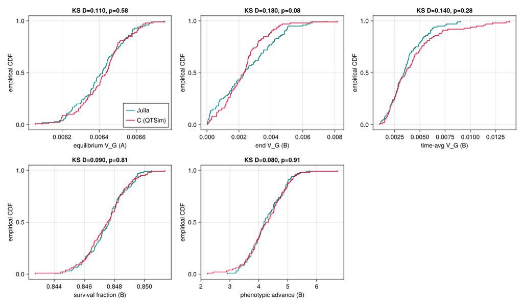

Figure 2: Empirical CDFs of five summary metrics: compositional Julia model (teal) vs. reference C simulation QTSim (crimson), R=100 replicates each. Overlapping curves indicate the two implementations draw from the same distribution; each panel is annotated with the two-sample KS statistic and p-value. Scenario B’s genetic-variance metrics (`end V_G`, `time-avg V_G`) are near-neutral, single-locus and heavy-tailed, so their *means* are unstable even at R=100 and their KS panels stay noisy (p≈0.08–0.28) — not rejected, but weak on their own. The clean, well-conditioned test of the same quantity is scenario A’s `equilibrium V_G`; definitive algorithmic parity is established separately by the RNG-locked test (tip below).

```julia
fig = Figure(size = (1200, 700))
positions = [(1,1), (1,2), (1,3), (2,1), (2,2)]
for (k, (name, jv, cv)) in enumerate(metrics)
    r, c = positions[k]
    ax = Axis(fig[r, c], xlabel = name, ylabel = "empirical CDF",
              title = @sprintf("KS D=%.3f, p=%.2f", ks_D(jv, cv), ks_p(jv, cv)))
    ecdfplot!(ax, jv, color = :teal, label = "Julia")
    ecdfplot!(ax, cv, color = :crimson, label = "C (QTSim)")
    k == 1 && axislegend(ax, position = :rb)
end
fig
```

```julia
println("| metric | Julia (mean ± sd) | C / QTSim (mean ± sd) | KS *D* | KS *p* | verdict |")
println("|:--|--:|--:|--:|--:|:--|")
for (name, jv, cv) in metrics
    D, pv = ks_D(jv, cv), ks_p(jv, cv)
    @printf("| %s | %.4g ± %.2g | %.4g ± %.2g | %.3f | %.2f | %s |\n",
            name, mean(jv), std(jv), mean(cv), std(cv), D, pv,
            pv > 0.05 ? "consistent" : "**CHECK**")
end
```

Table 1

| metric | Julia (mean ± sd) | C / QTSim (mean ± sd) | KS *D* | KS *p* | verdict |
| --- | --- | --- | --- | --- | --- |
| equilibrium V_G (A) | 0.006411 ± 0.00013 | 0.006423 ± 0.00013 | 0.110 | 0.58 | consistent |
| end V_G (B) | 0.002525 ± 0.0018 | 0.002317 ± 0.0014 | 0.180 | 0.08 | consistent |
| time-avg V_G (B) | 0.003673 ± 0.0017 | 0.004291 ± 0.0027 | 0.140 | 0.28 | consistent |
| survival fraction (B) | 0.8475 ± 0.0013 | 0.8475 ± 0.0014 | 0.090 | 0.81 | consistent |
| phenotypic advance (B) | 4.27 ± 0.6 | 4.276 ± 0.7 | 0.080 | 0.91 | consistent |

```julia
@printf("Directional-scenario extinctions — Julia: %d/%d,  C: %d/%d\n",
        extinct_note[1], R, extinct_note[2], R)
allp = [ks_p(jv, cv) for (_, jv, cv) in metrics]
println(all(>(0.05), allp) ?
    "All metrics: KS test does not reject equality of distribution ⇒ statistically consistent." :
    "At least one metric rejects — investigate.")
```

```
Directional-scenario extinctions — Julia: 0/100,  C: 0/100
All metrics: KS test does not reject equality of distribution ⇒ statistically consistent.
```

**TipExact algorithmic parity (RNG-locked)**

Distributional agreement still leaves the *random number generator* as a confound — Julia’s `MersenneTwister` is dSFMT, not GSL’s MT19937, and the two consume randomness with different Gaussian/Poisson algorithms. To eliminate it, `validate/gsl_locked.jl` re-implements the model drawing **all** randomness from the same GSL routines as QTSim, in QTSim’s exact draw order (and computing fitness and means with the same GSL functions). Seeded identically it is **bit-identical to QTSim — every generation, every seed**: `pheno_mean` and `geno_var` agree to all six printed decimals across 6500 generations (residual max |Δ| = 5×10⁻⁷ is exactly QTSim’s print-rounding floor). This proves the *algorithm* is identical to the reference; the finite-sample scatter in the eCDFs above is purely RNG sampling noise, not a structural deviation.

*Reproduce the numeric parity study from the command line with* `julia --project=. validate/compare_to_qtsim.jl`.